# Happiness Report (2020)

## 1. Introduction (Exploratory Data Analysis)

### a. Introduction (strategy)

1. Assess the general characteristics of the data set
2. Examine descriptive statistics for each variable
3. Visualize variable relations
4. Where possible, investigate data anomalies
5. Examine relations between key variables

### b. Summarizing numerical data

```r
library(ggplot2)
library(caTools)
library(dplyr)
library(broom)
library(ggpubr)
```

```r
# Importing the data set
data_2020 <- read.csv('2020_report.csv')
```

```r
head(data_2020)
```

|  | country | happiness_score | gdp_per_capita | social_support | health | freedom | generosity | government_trust | dystopia_residual | continent |
| --- | --- | --- | --- | --- | --- | --- | --- | --- | --- | --- |
| 1 | Finland | 7.8087 | 1.285190 | 1.499526 | 0.9612714 | 0.6623167 | 0.1596704 | 0.4778573 | 2.762835 | Europe |
| 2 | Denmark | 7.6456 | 1.326949 | 1.503449 | 0.9793326 | 0.6650399 | 0.2427934 | 0.4952603 | 2.432741 | Europe |
| 3 | Switzerland | 7.5599 | 1.390774 | 1.472403 | 1.0405332 | 0.6289545 | 0.2690558 | 0.4079459 | 2.350267 | Europe |
| 4 | Iceland | 7.5045 | 1.326502 | 1.547567 | 1.0008434 | 0.6619807 | 0.3623302 | 0.1445408 | 2.460688 | Europe |
| 5 | Norway | 7.4880 | 1.424207 | 1.495173 | 1.0080719 | 0.6702009 | 0.2879851 | 0.4341006 | 2.168266 | Europe |
| 6 | Netherlands | 7.4489 | 1.338946 | 1.463646 | 0.9756753 | 0.6136265 | 0.3363176 | 0.3685698 | 2.352117 | Europe |

```r
str(data_2020)
```

```
## 'data.frame':    138 obs. of  10 variables:
##  $ country          : chr  "Finland" "Denmark" "Switzerland" "Iceland" ...
##  $ happiness_score  : num  7.81 7.65 7.56 7.5 7.49 ...
##  $ gdp_per_capita   : num  1.29 1.33 1.39 1.33 1.42 ...
##  $ social_support   : num  1.5 1.5 1.47 1.55 1.5 ...
##  $ health           : num  0.961 0.979 1.041 1.001 1.008 ...
##  $ freedom          : num  0.662 0.665 0.629 0.662 0.67 ...
##  $ generosity       : num  0.16 0.243 0.269 0.362 0.288 ...
##  $ government_trust : num  0.478 0.495 0.408 0.145 0.434 ...
##  $ dystopia_residual: num  2.76 2.43 2.35 2.46 2.17 ...
##  $ continent        : chr  "Europe" "Europe" "Europe" "Europe" ...
```

```r
# summarizing the numerical data
num_data <- data_2020[, c(2,3,4,5,6,7,8,9)]
summary(num_data)
```

```
##  happiness_score gdp_per_capita   social_support       health
##  Min.   :2.567   Min.   :0.0000   Min.   :0.3524   Min.   :0.1087
##  1st Qu.:4.775   1st Qu.:0.6033   1st Qu.:1.0037   1st Qu.:0.5374
##  Median :5.551   Median :0.9380   Median :1.2197   Median :0.7666
##  Mean   :5.551   Mean   :0.8837   Mean   :1.1705   Mean   :0.7106
##  3rd Qu.:6.299   3rd Qu.:1.1866   3rd Qu.:1.3935   3rd Qu.:0.8647
##  Max.   :7.809   Max.   :1.5367   Max.   :1.5476   Max.   :1.1378
##     freedom         generosity     government_trust  dystopia_residual
##  Min.   :0.0000   Min.   :0.0000   Min.   :0.00000   Min.   :0.2572
##  1st Qu.:0.3816   1st Qu.:0.1143   1st Qu.:0.05729   1st Qu.:1.6852
##  Median :0.4934   Median :0.1705   Median :0.09736   Median :2.0550
##  Mean   :0.4693   Mean   :0.1872   Mean   :0.13201   Mean   :1.9973
##  3rd Qu.:0.5852   3rd Qu.:0.2552   3rd Qu.:0.16298   3rd Qu.:2.3765
##  Max.   :0.6933   Max.   :0.5698   Max.   :0.53316   Max.   :3.4408
```

### c. Anomalies in numerical data investigation

**The dots in the boxplots below show the outlier values**

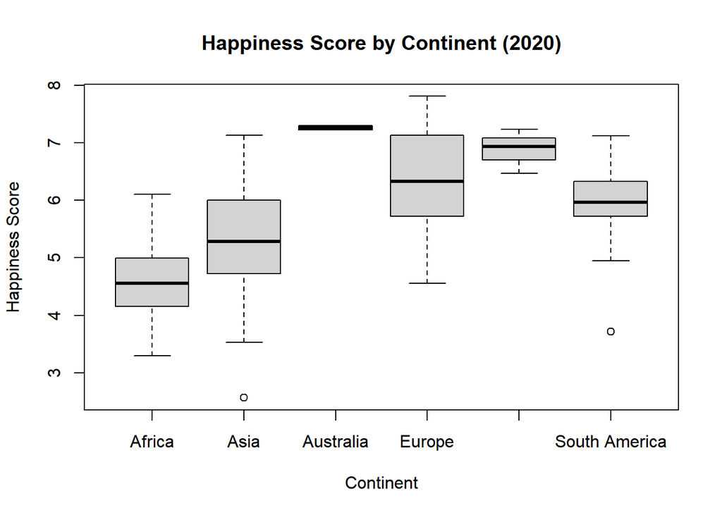

```r
plot(factor(data_2020$continent), data_2020$happiness_score, xlab='Continent',
     ylab='Happiness Score', main='Happiness Score by Continent (2020)')
```

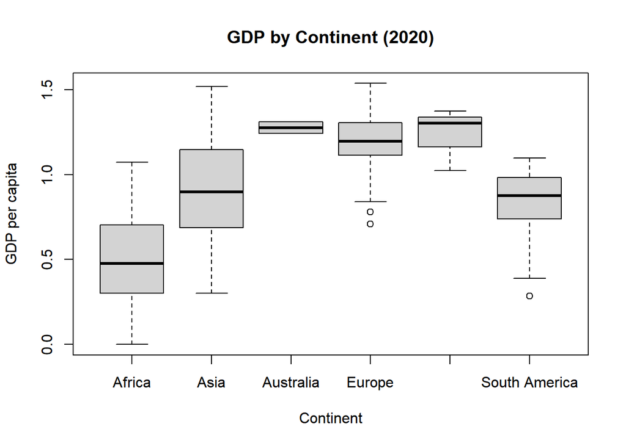

```r
plot(factor(data_2020$continent), data_2020$gdp_per_capita, xlab='Continent',
     ylab='GDP per capita', main='GDP by Continent (2020)')
```

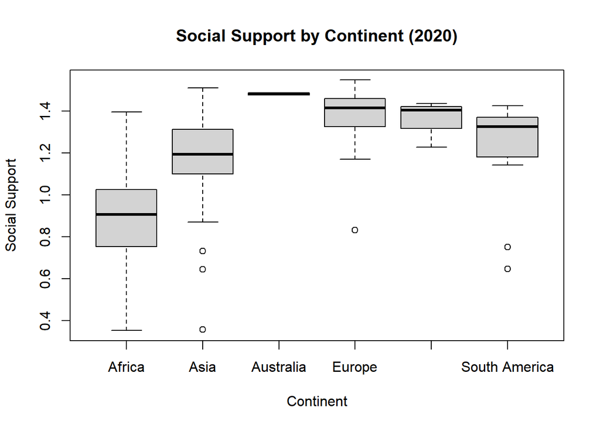

```r
plot(factor(data_2020$continent), data_2020$social_support, xlab='Continent',
     ylab='Social Support', main='Social Support by Continent (2020)')
```

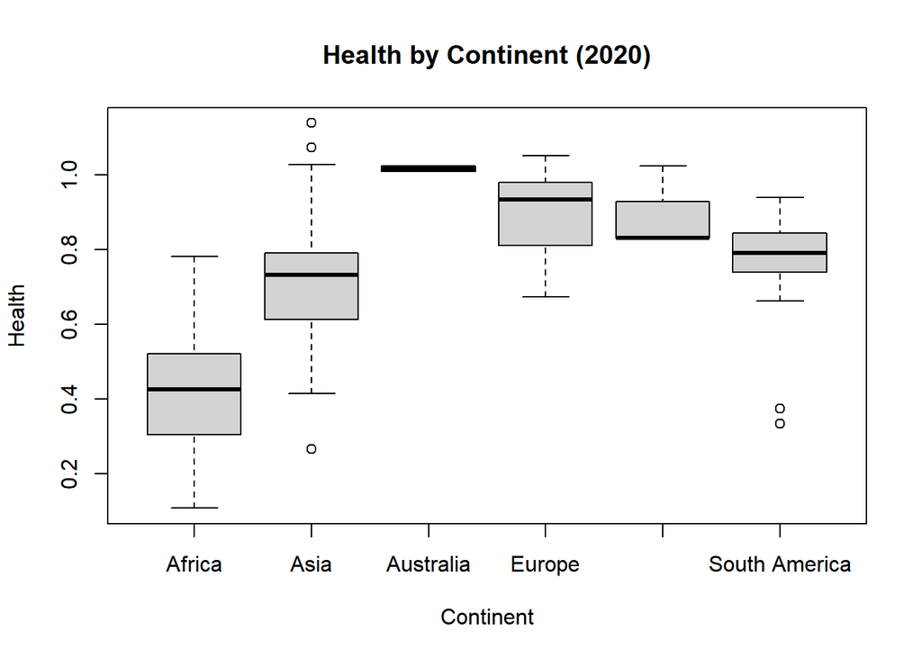

```r
plot(factor(data_2020$continent), data_2020$health, xlab='Continent',
     ylab='Health', main='Health by Continent (2020)')
```

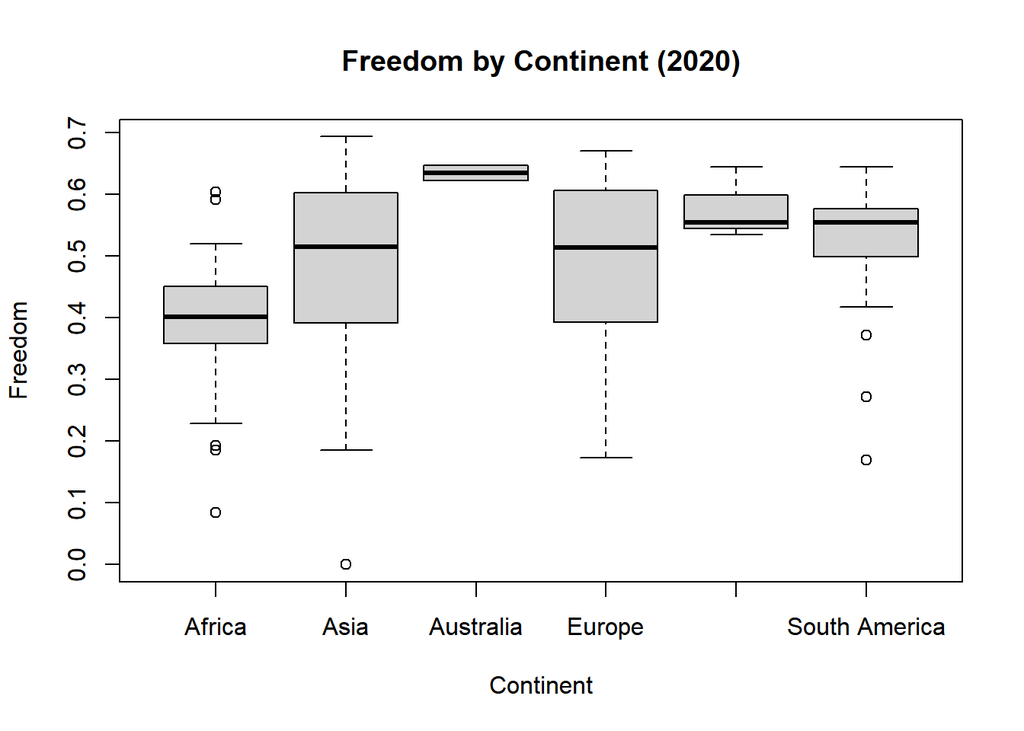

```r
plot(factor(data_2020$continent), data_2020$freedom, xlab='Continent',
     ylab='Freedom', main='Freedom by Continent (2020)')
```

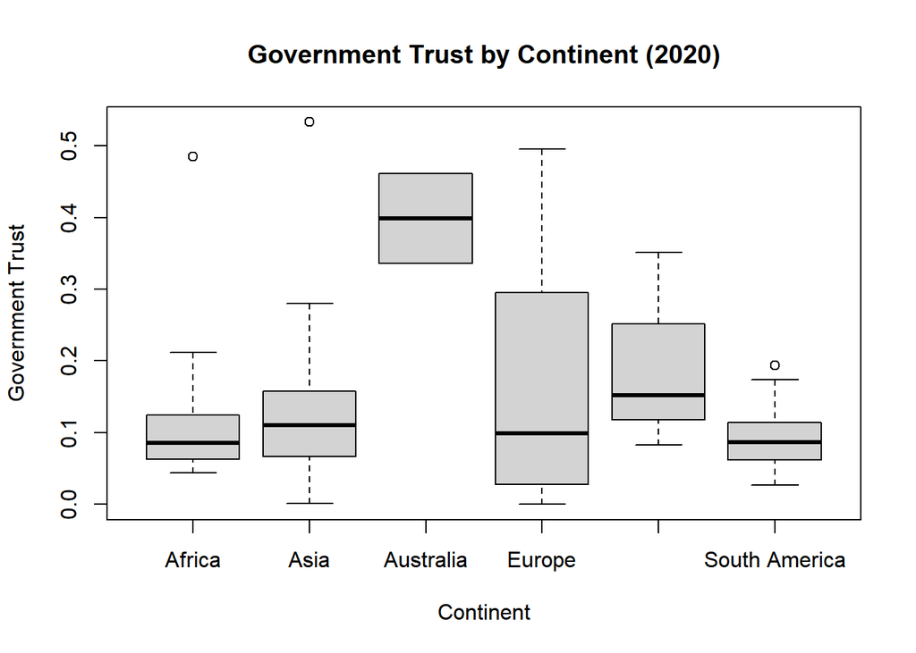

```r
plot(factor(data_2020$continent), data_2020$government_trust, xlab='Continent',
     ylab='Government Trust', main='Government Trust by Continent (2020)')
```

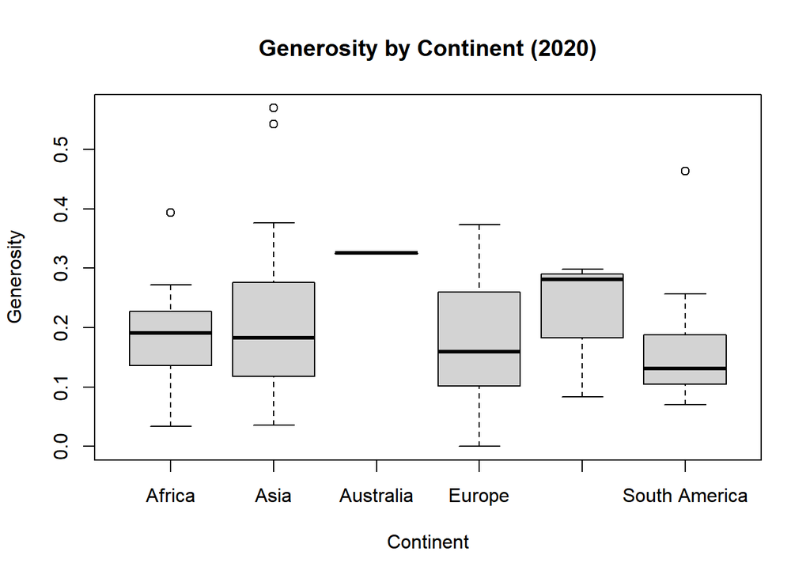

```r
plot(factor(data_2020$continent), data_2020$generosity, xlab='Continent',
     ylab='Generosity', main='Generosity by Continent (2020)')
```

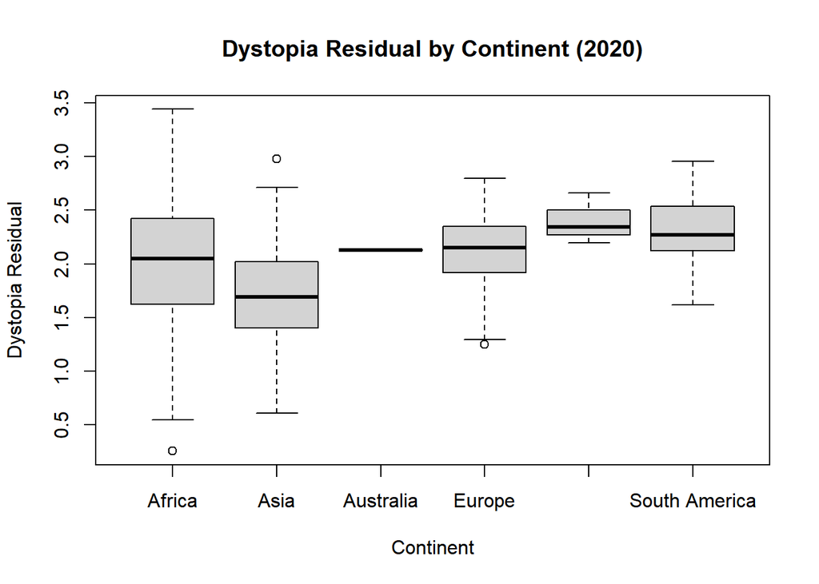

```r
plot(factor(data_2020$continent), data_2020$dystopia_residual, xlab='Continent',
     ylab='Dystopia Residual', main='Dystopia Residual by Continent (2020)')
```

Checking the data set for any missing values:

```r
# checking for any missing values
any(is.na(data_2020))
```

```
## [1] FALSE
```

### d. Visualization between variables relations

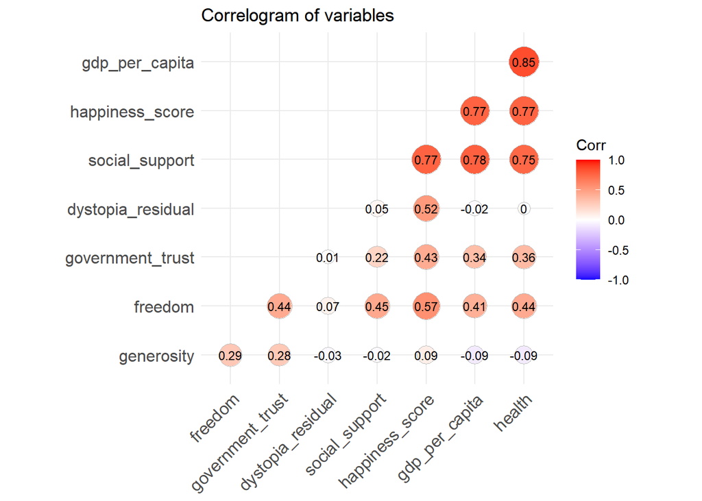

```r
# plotting variable relations (2020)

library(ggcorrplot)

num_data <- data_2020[, c(2,3,4,5,6,7,8,9)]

ggcorrplot(cor(num_data), hc.order = TRUE, type = "lower", lab = TRUE, lab_size = 3, method="circle", colors = c("blue", "white", "red"), outline.color = "gray", show.legend = TRUE, show.diag = FALSE, title="Correlogram of variables")
```

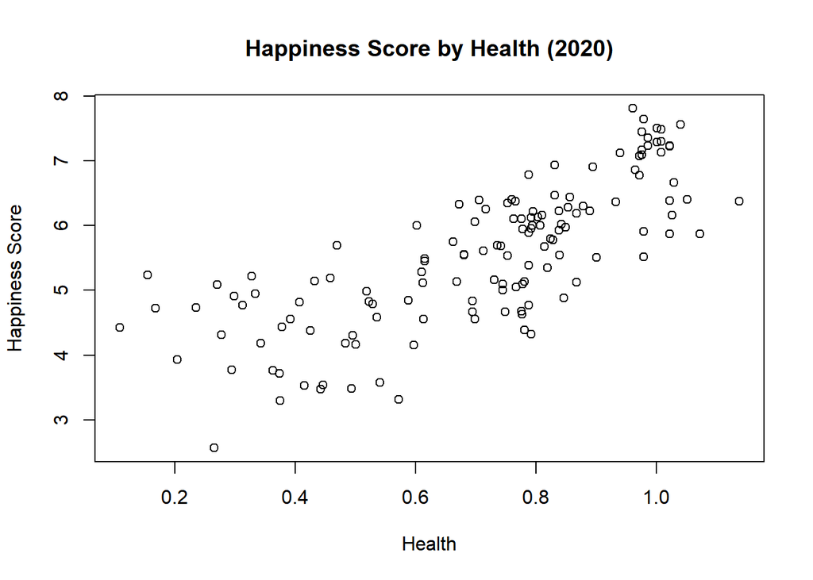

```r
plot(data_2020$health, data_2020$happiness_score, xlab='Health',
     ylab='Happiness Score', main='Happiness Score by Health (2020)')
```

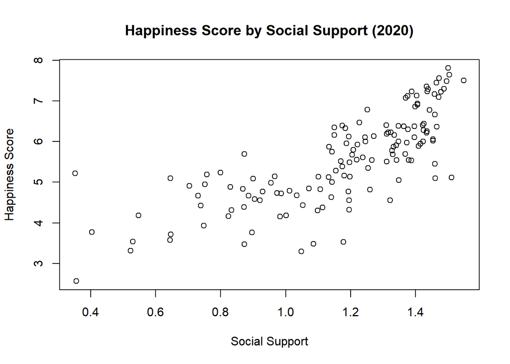

```r
plot(data_2020$social_support, data_2020$happiness_score, xlab='Social Support',
     ylab='Happiness Score', main='Happiness Score by Social Support (2020)')
```

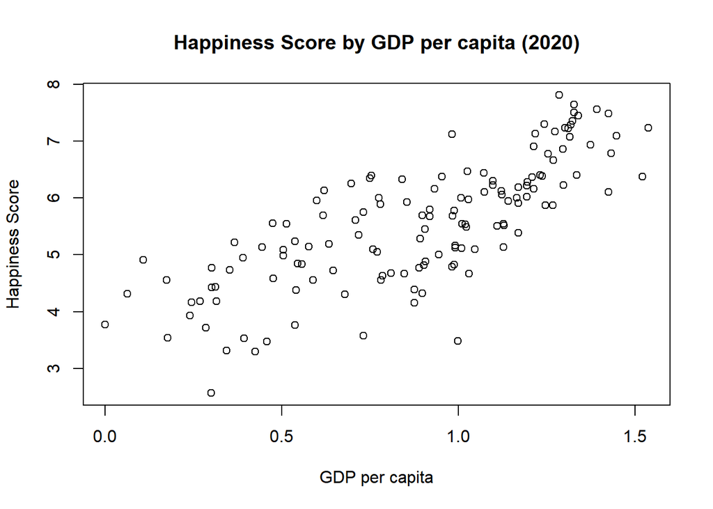

```r
plot(data_2020$gdp_per_capita, data_2020$happiness_score, xlab='GDP per capita',
     ylab='Happiness Score', main='Happiness Score by GDP per capita (2020)')
```

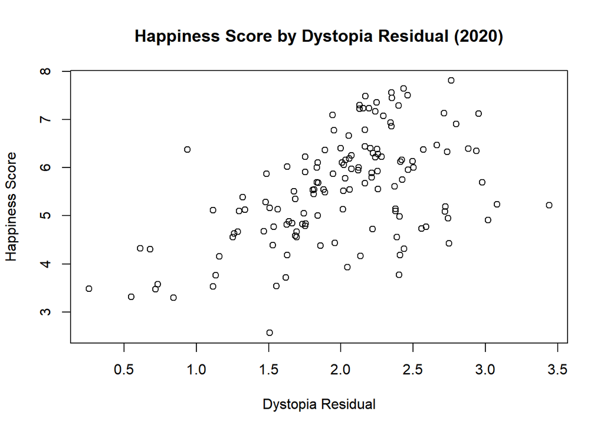

```r
plot(data_2020$dystopia_residual, data_2020$happiness_score, xlab='Dystopia Residual', ylab='Happiness Score', main='Happiness Score by Dystopia Residual (2020)')
```

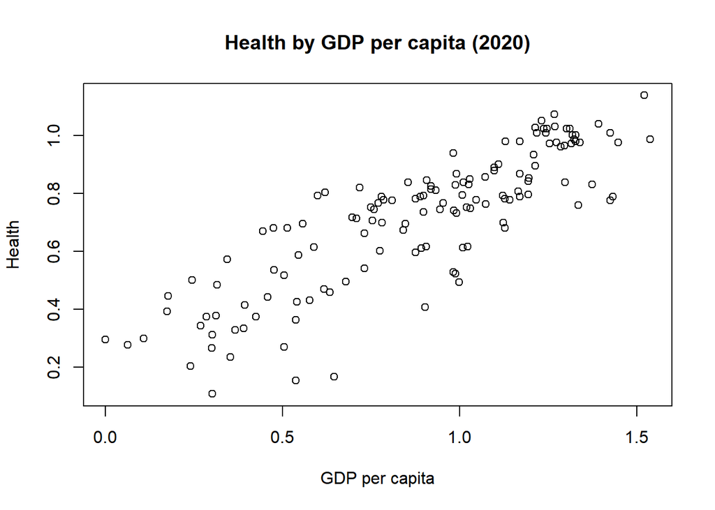

```r
plot(data_2020$gdp_per_capita, data_2020$health, xlab='GDP per capita',
     ylab='Health', main='Health by GDP per capita (2020)')
```

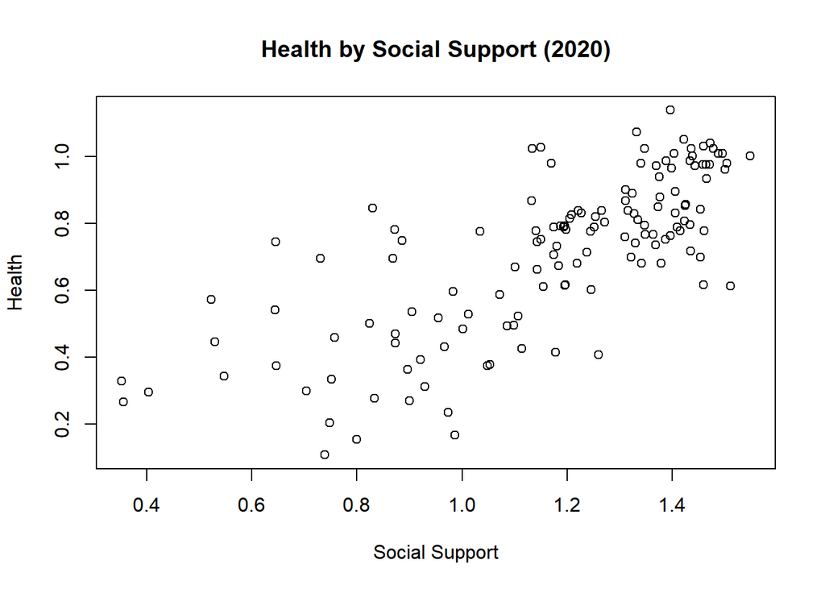

```r
plot(data_2020$social_support, data_2020$health, xlab='Social Support',
     ylab='Health', main='Health by Social Support (2020)')
```

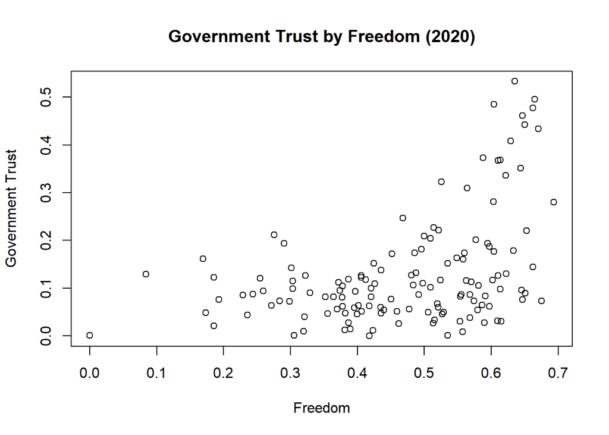

```r
plot(data_2020$freedom, data_2020$government_trust, xlab='Freedom',
     ylab='Government Trust', main='Government Trust by Freedom (2020)')
```

## 2. Simple Linear Regression Models

### a. Evaluation of variables relations

For this report, the two variables of interest for linear regression are: **social support** and **happiness score**.

```r
# Correlation coefficient
cor(data_2020$social_support, data_2020$happiness_score)
```

```
## [1] 0.7658867
```

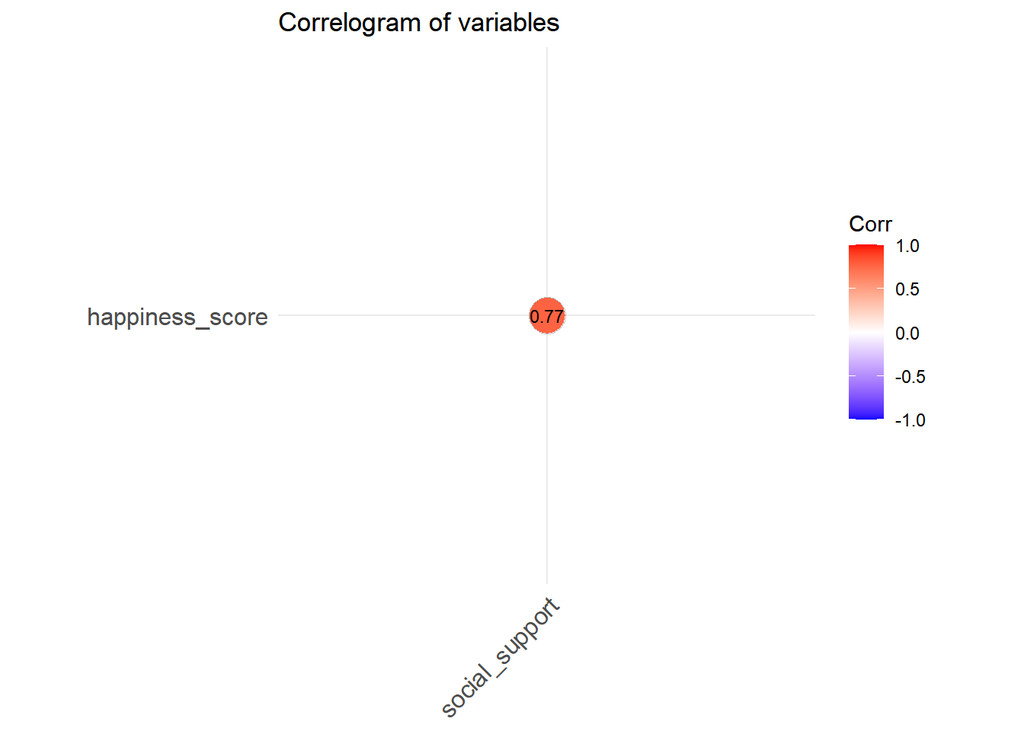

```r
# correlation plot of selected variables
library(ggcorrplot)

lin <- data_2020[,c(2,4)]
ggcorrplot(cor(lin), hc.order = TRUE, type = "lower", lab = TRUE, lab_size = 3, method="circle", colors = c("blue", "white", "red"), outline.color = "gray", show.legend = TRUE, show.diag = FALSE, title="Correlogram of variables")
```

It can be noted above that there is a strong correlation between social support and the happiness score.

### b. Model Definition

```r
# splitting the data
split_2020 <- sample.split(data_2020$happiness_score, SplitRatio = 0.8)
training_set <- subset(data_2020, split_2020 == TRUE)
test_set <- subset(data_2020, split_2020 == FALSE)
```

```r
# fitting the data into linear regression model
lm_2020 <- lm(happiness_score ~ social_support, data=training_set)
```

```r
# printing out the intercept and slope of the linear regression model
coef(lm_2020)
```

```
##    (Intercept) social_support
##       1.870338       3.174948
```

```r
# summary of the linear regression model
summary(lm_2020)
```

```
##
## Call:
## lm(formula = happiness_score ~ social_support, data = training_set)
##
## Residuals:
##      Min       1Q   Median       3Q      Max
## -2.08137 -0.39389 -0.01532  0.57868  2.22672
##
## Coefficients:
##                Estimate Std. Error t value Pr(>|t|)
## (Intercept)      1.8703     0.3210   5.827  5.9e-08 ***
## social_support   3.1749     0.2634  12.052  < 2e-16 ***
## ---
## Signif. codes:  0 '***' 0.001 '**' 0.01 '*' 0.05 '.' 0.1 ' ' 1
##
## Residual standard error: 0.7161 on 108 degrees of freedom
## Multiple R-squared:  0.5735, Adjusted R-squared:  0.5696
## F-statistic: 145.2 on 1 and 108 DF,  p-value: < 2.2e-16
```

### c. Statistical Inference

A correlation test is conducted below to test the relationship between the variables: **social_support** and **happiness_score**

```r
# correlation test using Pearson correlation test
cor.test(data_2020$social_support, data_2020$happiness_score, method="pearson")
```

```
##
##  Pearson's product-moment correlation
##
## data:  data_2020$social_support and data_2020$happiness_score
## t = 13.891, df = 136, p-value < 2.2e-16
## alternative hypothesis: true correlation is not equal to 0
## 95 percent confidence interval:
##  0.6866634 0.8271324
## sample estimates:
##       cor
## 0.7658867
```

The results show that the p-value is less than the significance level (0.05), so the null hypothesis (true correlation is equal to 0) is rejected. The alternative hypothesis (true correlation is not equal to 0) is not rejected, so this indicates that the two variables are significantly correlated. This is backed by the correlation coefficient which is approximately 0.77, which signifies a strong positive correlation between social_support and happiness_score.

### d. Prediction

```r
# using the simple linear regression to predict the happiness score using the test set
ypred <- predict(lm_2020, newdata = test_set)

ypred
```

```
##       18       26       28       32       39       40       46       51
## 6.330463 6.029362 5.598575 6.520614 6.046422 6.419612 5.822449 6.388319
##       58       59       66       74       77       84       85       91
## 6.341583 5.469334 6.089491 5.581768 6.502367 5.618723 4.938506 3.918842
##       93       97      103      109      115      116      119      127
## 6.151904 4.104867 5.081692 4.191841 5.663625 5.211423 5.405083 4.245151
##      130      132      134      138
## 3.923486 3.554229 5.317363 3.001997
```

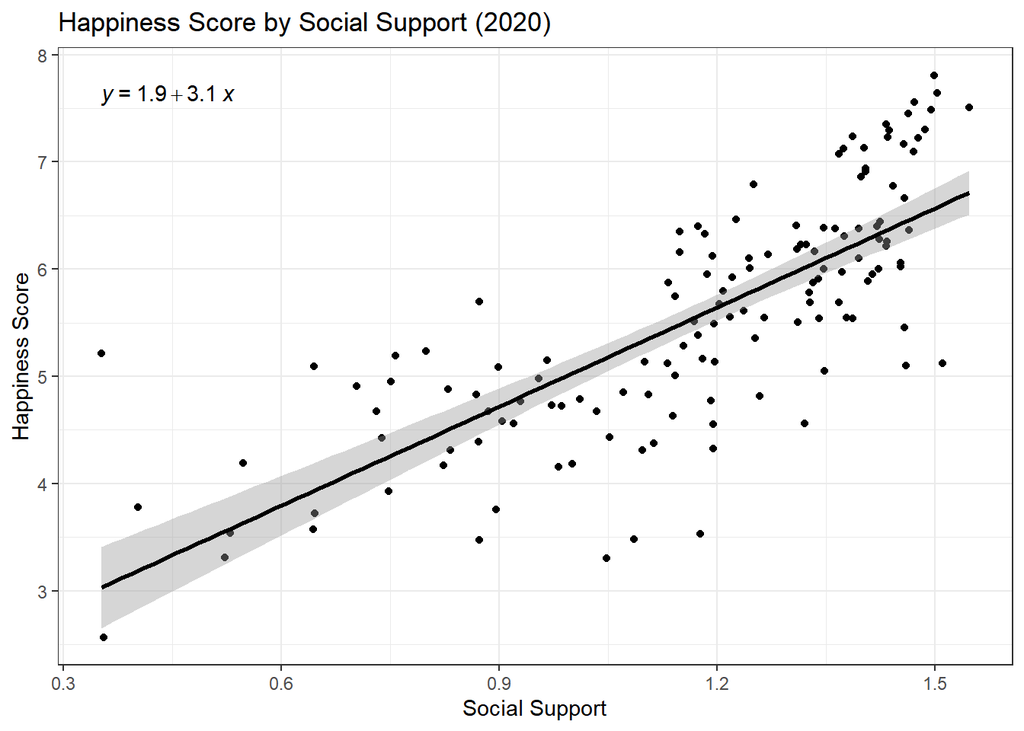

```r
# linear regression graph (whole data set)
happiness_graph <- ggplot(data_2020, aes(x=social_support, y=happiness_score)) + geom_point()

happiness_graph <- happiness_graph + geom_smooth(method="lm", col="black")

happiness_graph <- happiness_graph + stat_regline_equation()

happiness_graph <- happiness_graph + theme_bw() + labs(
  title="Happiness Score by Social Support (2020)",
  x = "Social Support",
  y = "Happiness Score")

happiness_graph
```

## 3. Multiple Linear Regression

### a. Evaluation of variables

```r
# correlation matrix of selected variables
num_data1 <- data_2020[, c(2, 3, 4, 5, 6)]
cor(num_data1)
```

```
##                 happiness_score gdp_per_capita social_support    health
## happiness_score       1.0000000      0.7721479      0.7658867 0.7657605
## gdp_per_capita        0.7721479      1.0000000      0.7754927 0.8504575
## social_support        0.7658867      0.7754927      1.0000000 0.7456943
## health                0.7657605      0.8504575      0.7456943 1.0000000
## freedom               0.5731768      0.4075997      0.4485964 0.4362108
##                   freedom
## happiness_score 0.5731768
## gdp_per_capita  0.4075997
## social_support  0.4485964
## health          0.4362108
## freedom         1.0000000
```

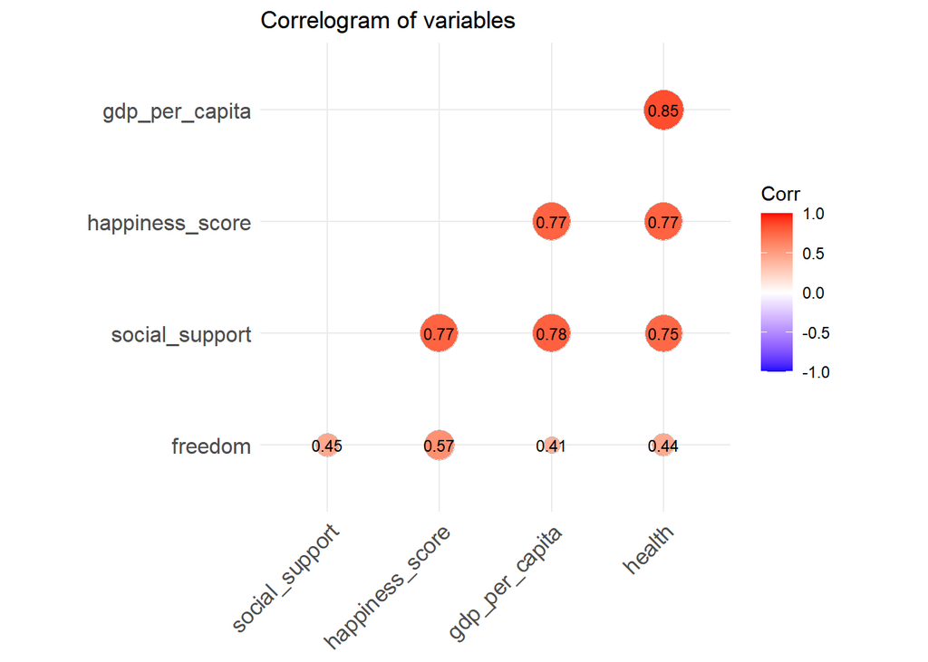

```r
# correlation plot of selected variables
ggcorrplot(cor(num_data1), hc.order = TRUE, type = "lower", lab = TRUE, lab_size = 3, method="circle", colors = c("blue", "white", "red"), outline.color = "gray", show.legend = TRUE, show.diag = FALSE, title="Correlogram of variables")
```

Scatter plots showing relationship between the selected variables

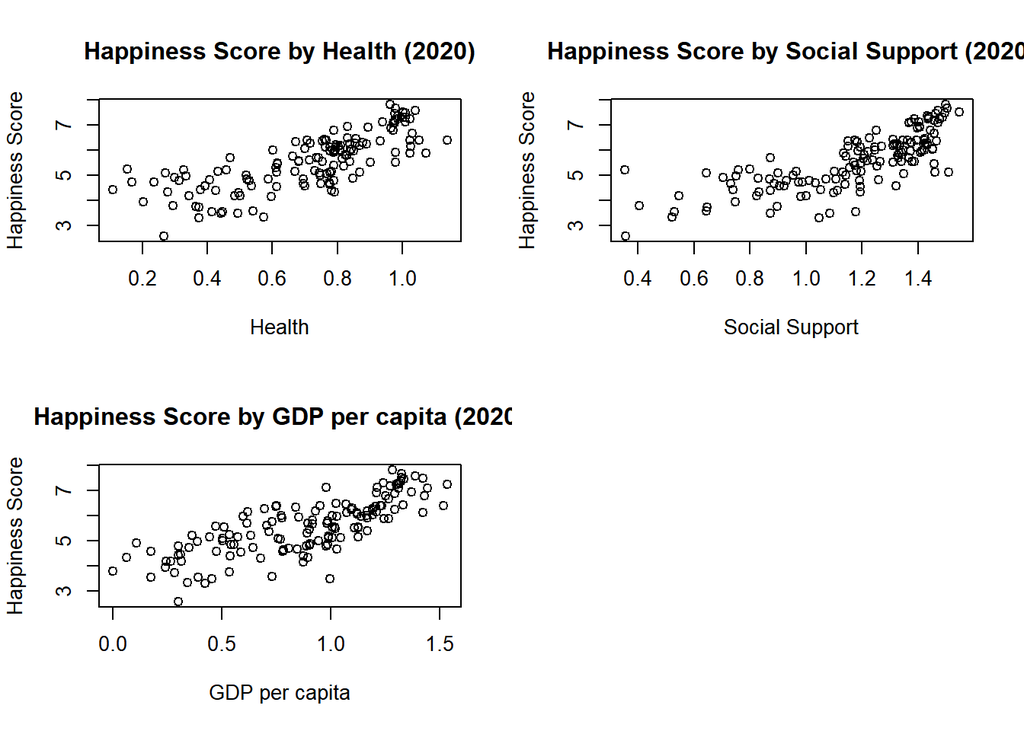

```r
par(mfrow=c(2,2))
plot(data_2020$health, data_2020$happiness_score, xlab='Health',
     ylab='Happiness Score', main='Happiness Score by Health (2020)')

plot(data_2020$social_support, data_2020$happiness_score, xlab='Social Support',
     ylab='Happiness Score', main='Happiness Score by Social Support (2020)')

plot(data_2020$gdp_per_capita, data_2020$happiness_score, xlab='GDP per capita',
     ylab='Happiness Score', main='Happiness Score by GDP per capita (2020)')
```

### b. Summary form Evaluation of Variables

```r
# fitting the data into the multiple linear regression model
multiple_lm_2020 <- lm(happiness_score ~ gdp_per_capita + social_support + health + freedom, data = training_set)
```

```r
# summary of the multiple linear regression model
summary(multiple_lm_2020)
```

```
##
## Call:
## lm(formula = happiness_score ~ gdp_per_capita + social_support +
##     health + freedom, data = training_set)
##
## Residuals:
##      Min       1Q   Median       3Q      Max
## -1.46031 -0.41074  0.07139  0.44546  1.50412
##
## Coefficients:
##                Estimate Std. Error t value Pr(>|t|)
## (Intercept)      1.9351     0.3103   6.237 9.52e-09 ***
## gdp_per_capita   1.0314     0.3412   3.023 0.003149 **
## social_support   1.1293     0.3783   2.985 0.003529 **
## health           0.7478     0.4890   1.529 0.129258
## freedom          1.8621     0.4943   3.767 0.000273 ***
## ---
## Signif. codes:  0 '***' 0.001 '**' 0.01 '*' 0.05 '.' 0.1 ' ' 1
##
## Residual standard error: 0.5974 on 105 degrees of freedom
## Multiple R-squared:  0.7115, Adjusted R-squared:  0.7005
## F-statistic: 64.72 on 4 and 105 DF,  p-value: < 2.2e-16
```

```r
# using the multiple linear regression to predict the happiness score using the test set
ypred <- predict(multiple_lm_2020, newdata = test_set)

ypred
```

```
##       18       26       28       32       39       40       46       51
## 6.555938 6.380076 5.708274 6.737246 6.521719 6.161944 6.452839 6.065728
##       58       59       66       74       77       84       85       91
## 5.948493 5.747160 6.052723 5.474167 5.638730 5.707376 4.832260 4.841365
##       93       97      103      109      115      116      119      127
## 5.331924 3.875678 5.014072 5.058094 4.905800 4.476487 4.412749 3.891798
##      130      132      134      138
## 3.554259 3.957325 5.507453 2.846739
```